# `MCPanel`: Imputation Estimators for Causal Effects in Panel Data

Fork of [Athey et al’s MCPanel](https://github.com/susanathey/MCPanel/) package with additional imputation methods for causal inference in panel data. Supported imputation methods:

- matching (via `filling`)
- kernel matching (kernel PCA via `kernlab` followed by `filling`)
- dynamic factor model (`dfms`)
- sparse dynamic factor model (`sparseDFM`)
- matrix completion
- two-way FE / DID
- synthetic control
- horizontal ridge regression
- vertical ridge regression

These methods can all be implemented using the `imputation_ATT` function. Inference can be performed using the bootstrap / jack-knife (when number of treated units > 1) using the `boot` library [implementation in progress].

## Example

using Abadie, Diamond, Hainmueller (2010) California Prop 99 data.

```r
# install.packages("apoorvalal/MCPanel")
pacman::p_load(MCPanel, synthdid) # for data
data(california_prop99)
```

`imputation_ATT` takes a panel data set, identifiers for unit, time, treatment, and outcome, and a vector of method names (must be supported by `imputationY`: includes `"did", "dfm", "sdfm", "knn", "kknn", "nuclear", "hardimpute", "svdimpute", "optspace", "mc", "sc", "env", "enh"`).

```r
# call all with defaults
est = imputation_ATT(
        california_prop99,
        "State", "Year", "treated", "PacksPerCapita",
        # method specific arguments are passed as lists
        # check docs for imputationY for details
        dfm_args = list(r = 4, p = 1),
        sdfm_args = list(r = 4, q = 2)
)
```

```
## Converged after 67 iterations.
```

```r
# The print method returns ATT estimates.
print(est)
```

```
## ATT estimates

##               DFM        sparse DFM               knn        kernel KNN
##            -55.30            -55.42            -26.69            -23.23
##               did matrix completion synthetic control   elastic net (V)
##            -27.35            -20.00            -19.46            -11.49
##   elastic net (H)
##            -18.86
```

The plot method makes an event study figure. The legend contains ATT estimates, and its width may need to be customized.

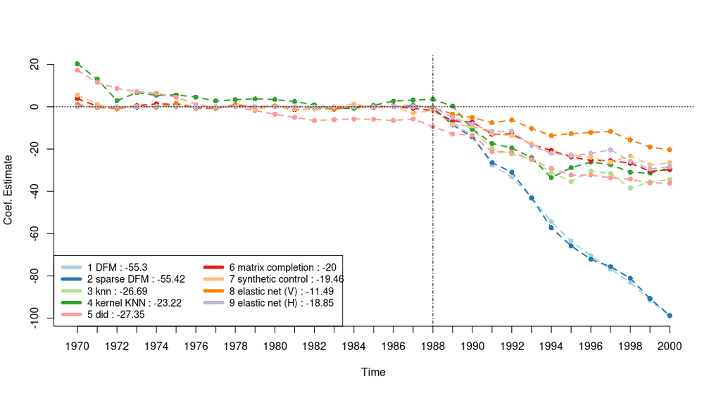

```r
plot(est, prec = 2, twd = 5.5)
```

Factor models perform poorly here, as does difference in differences. Most other methods have good pre-trends and broadly agree.

#### References

Susan Athey, Mohsen Bayati, Nikolay Doudchenko, Guido Imbens, and Khashayar Khosravi. **Matrix Completion Methods for Causal Panel Data Models** [[link](http://arxiv.org/abs/1710.10251)]

Licheng Liu, Ye Wang, and Yiqing Xu. “A Practical Guide to Counterfactual Estimators for Causal Inference with Time‐Series Cross‐Sectional Data.” American Journal of Political Science (2022). [link](https://arxiv.org/abs/2107.00856)